# Supplement Sales Analysis

Tanisha Alam

2025-05-06

# Introduction

Supplementation has recently been increasing in popularity and more research is being done on its potential uses. This project aims to investigate how supplement sales vary across seasons and what factors influence revenue trends using weekly sales data from 2020 to 2025. Understanding these patterns can help inform marketing strategies and inventory decisions.

## The Data

The dataset comes from [Kaggle](https://www.kaggle.com/datasets/zahidmughal2343/supplement-sales-data) and contains 4,384 entries of weekly sales data for a variety of health and wellness supplements from January 2020 to April 2025.

```
## # A tibble: 4,384 × 10
##    Date       `Product Name`    Category    `Units Sold` Price Revenue Discount
##    <date>     <chr>             <chr>              <dbl> <dbl>   <dbl>    <dbl>
##  1 2020-01-06 Whey Protein      Protein              143  32.0   4573.     0.03
##  2 2020-01-06 Vitamin C         Vitamin              139  42.5   5909.     0.04
##  3 2020-01-06 Fish Oil          Omega                161  12.9   2079.     0.25
##  4 2020-01-06 Multivitamin      Vitamin              140  16.1   2250.     0.08
##  5 2020-01-06 Pre-Workout       Performance          157  35.5   5569.     0.25
##  6 2020-01-06 BCAA              Amino Acid           154  41.2   6343.     0.13
##  7 2020-01-06 Creatine          Performance          134  32.5   4354.     0.05
##  8 2020-01-06 Zinc              Mineral              147  46.7   6862.     0.19
##  9 2020-01-06 Collagen Peptides Protein              147  11.0   1611.     0.06
## 10 2020-01-06 Magnesium         Mineral              134  20.8   2782.     0
## # ℹ 4,374 more rows
## # ℹ 3 more variables: `Units Returned` <dbl>, Location <chr>, Platform <chr>
```

# Data Wrangling

- Using `separate_wider_delim()`, use the `Date` column to create three new columns: `year`, `month`, and `day`.
- Using `mutate()`, use the month values to assign seasons.

Now we have a new column called `Season`. This allows us to analyze trends by time period.

```r
data_new <- data |>
  separate_wider_delim(
    cols = Date,
    delim = "-",
    names = c("year", "month", "day")
  ) |>
  mutate(
    month = as.integer(month),
    Season = case_when(
      month %in% c(12, 01, 02) ~ "Winter",
      month %in% c(03, 04, 05) ~ "Spring",
      month %in% c(06, 07, 08) ~ "Summer",
      month %in% c(09, 10, 11) ~ "Fall"
      )
    )

data_new
```

```
## # A tibble: 4,384 × 13
##    year  month day   `Product Name` Category `Units Sold` Price Revenue Discount
##    <chr> <int> <chr> <chr>          <chr>           <dbl> <dbl>   <dbl>    <dbl>
##  1 2020      1 06    Whey Protein   Protein           143  32.0   4573.     0.03
##  2 2020      1 06    Vitamin C      Vitamin           139  42.5   5909.     0.04
##  3 2020      1 06    Fish Oil       Omega             161  12.9   2079.     0.25
##  4 2020      1 06    Multivitamin   Vitamin           140  16.1   2250.     0.08
##  5 2020      1 06    Pre-Workout    Perform…          157  35.5   5569.     0.25
##  6 2020      1 06    BCAA           Amino A…          154  41.2   6343.     0.13
##  7 2020      1 06    Creatine       Perform…          134  32.5   4354.     0.05
##  8 2020      1 06    Zinc           Mineral           147  46.7   6862.     0.19
##  9 2020      1 06    Collagen Pept… Protein           147  11.0   1611.     0.06
## 10 2020      1 06    Magnesium      Mineral           134  20.8   2782.     0
## # ℹ 4,374 more rows
## # ℹ 4 more variables: `Units Returned` <dbl>, Location <chr>, Platform <chr>,
## #   Season <chr>
```

- Using `group_by()`, groups dataset by `Season` and `Category`
- Using `summarise()`, calculates summary statistics within each group

```r
season_summary <- data_new |>
  group_by(Season, Category) |>
  summarise(
    total_units = sum(`Units Sold`),
    average_price = mean(Price),
    total_revenue = sum(Revenue))

season_summary
```

```
## # A tibble: 40 × 5
## # Groups:   Season [4]
##    Season Category    total_units average_price total_revenue
##    <chr>  <chr>             <dbl>         <dbl>         <dbl>
##  1 Fall   Amino Acid         9823          34.0       336434.
##  2 Fall   Fat Burner         9607          37.0       355806.
##  3 Fall   Herbal             9800          35.1       346264.
##  4 Fall   Hydration          9612          34.7       330973.
##  5 Fall   Mineral           29161          33.8       990392.
##  6 Fall   Omega              9821          36.0       357681.
##  7 Fall   Performance       19448          34.8       677742.
##  8 Fall   Protein           19493          33.1       642879.
##  9 Fall   Sleep Aid          9820          33.4       329970.
## 10 Fall   Vitamin           29376          33.5       981130.
## # ℹ 30 more rows
```

# Data Visualization

This bar chart compares demand for each product category across seasons.

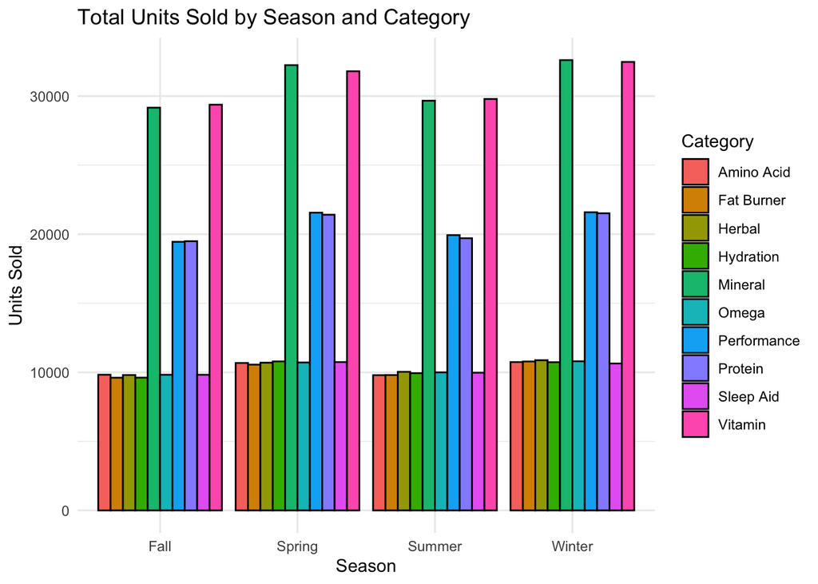

```r
season_summary |>
  ggplot(aes(x = Season, y = total_units, fill = Category)) +
  geom_col(position = "dodge", color = "black") +
  labs(title = "Total Units Sold by Season and Category", x = "Season", y = "Units Sold") +
  theme_minimal()
```